# Mini Project #04: Just The Facts

Author

Matthew Kelsall

[figure not shown]

## Introduction

In this report, we examine key outputs and historical patterns from the Bureau of Labor Statistics (BLS). The recent dismissal of Dr. Erika McEntarfer in August prompted scrutiny of the agency, as many economists raised concerns about how leadership changes could affect the interpretation of economic data. Given the major influence BLS reports have on markets and public perception, understanding their production and revision processes is essential. We will analyze trends in the Current Employment Statistics (CES) estimates and revisions dating back to 1979 to identify long-term patterns and anomalies. This report will serve as a fact-checking exercise, evaluating the evidence behind claims that the BLS has produced politically biased or misleading figures.

## Data Acquisition

We begin by gathering the data sources necessary for our analysis. Our code retrieves the CES Total Nonfarm Payroll, seasonally adjusted, for every month from January 1979 through June 2025 to ensure a complete long-term view of employment trends.

```r
library(httr2)
library(rvest)
library(dplyr)
library(tidyr)
library(lubridate)
library(readr)
library(stringr)
library(purrr)
library(DT)
library(ggplot2)

url <- "https://data.bls.gov/pdq/SurveyOutputServlet"

resp <- request(url) |>
  req_user_agent("httr2 + rvest CES scraper") |>
  req_headers(Referer = "https://data.bls.gov/toppicks?survey=ce") |>
  req_body_form(
    request_action       = "get_data",
    reformat             = "true",
    from_year            = "1979",
    to_year              = "2025",
    series_id            = "CES0000000001",
    years_option         = "specific_years",
    output_view          = "data",
    delimiter            = "comma",
    output_format        = "html",
    include_graphs       = "false",
    annualAveragesRequested = "false"
  ) |>
  req_perform()

# Parse HTML with rvest
html <- resp_body_html(resp)

tables <- html |> html_elements("table") |> html_table(fill = TRUE)

raw <- tables[[2]]   # main data table

# Tidy
df <- raw |>
  select(Year, Jan:Dec) |>
  pivot_longer(
    cols = Jan:Dec,
    names_to = "Month",
    values_to = "Level_raw"
  ) |>
  mutate(
    Level  = parse_number(Level_raw),
    Month3 = str_sub(Month, 1, 3),
    Date   = ymd(paste0(Year, "-", Month3, "-01"))
  ) |>
  filter(!is.na(Date), !is.na(Level)) |>
  arrange(Date) |>
  select(Date, Level)

df_final <- df |> filter(Date >= as.Date("1979-01-01"))
#df_final


datatable(
  df_final |>
    slice(1:2),
  style = "bootstrap5",
  class = "table table-striped table-hover",
  colnames = c(
    "Date",
    "Level"
  ),
  options = list(
    searching = FALSE,
    info = FALSE,
    lengthChange = TRUE,
    paging = FALSE,
    initComplete = JS('function() { $("html").attr("data-bs-theme", "light"); }')
  )
)
```

|  | Date | Level |
| --- | --- | --- |
| 1 | 1979-01-01 | 88808 |
| 2 | 1979-02-01 | 89055 |

Next we will do the same for CES Revisions for each month from January 1979 to June 2025.

```r
# 1. Fetch CES Revisions page
rev_req <- request("https://www.bls.gov/web/empsit/cesnaicsrev.htm") |>
  req_user_agent("httr2 + rvest CES Revisions scraper")
rev_resp <- rev_req |> req_perform()
rev_page <- rev_resp |> resp_body_html()

# 2. Extract all tables
rev_tbl_list <- rev_page |> html_elements("table") |> html_table(header = FALSE)

# 3. Identify which table contains 1979 in the 2nd column
year_table_candidates <- which(
  vapply(
    rev_tbl_list,
    function(tbl) {
      ncol(tbl) >= 2 && any(grepl("1979", as.character(tbl[[2]])))
    },
    logical(1)
  )
)

# Start of year-by-year blocks
year_table_index <- min(year_table_candidates)

# There are 47 years from 1979 to 2025
revision_tables <- rev_tbl_list[seq(from = year_table_index, length.out = 47)]

# 4. Function to extract date, original, final, revision from one table
extract_revisions_from_tbl <- function(tbl) {
  tbl |>
    select(
      month    = 1,   # Month names
      year_col = 2,   # Year
      original = 3,   # 1st estimate (SA)
      final    = 5    # 3rd estimate (SA)
    ) |>
    filter(str_detect(year_col, "^[0-9]{4}$")) |>
    slice(1:12) |>  # Only 12 months
    mutate(
      month    = str_sub(month, 1, 3),
      date     = ym(str_c(year_col, " ", month)),
      original = parse_number(original),
      final    = parse_number(final),
      revision = final - original
    ) |>
    select(date, original, final, revision) |>
    drop_na(date) |>
    arrange(date)
}

# 5. Apply to all tables and combine
ces_revisions <- map_dfr(revision_tables, extract_revisions_from_tbl) |>
  filter(date >= as.Date("1979-01-01"),
         date <= as.Date("2025-06-01")) |>
  arrange(date)

# View result
#ces_revisions

datatable(
  ces_revisions |>
    slice(1:2),
  style = "bootstrap5",
  class = "table table-striped table-hover",
  colnames = c(
    "Date",
    "Original",
    "Final",
    "Revision"
  ),
  options = list(
    searching = FALSE,
    info = FALSE,
    lengthChange = TRUE,
    paging = FALSE,
    initComplete = JS('function() { $("html").attr("data-bs-theme", "light"); }')
  )
)
```

|  | Date | Original | Final | Revision |
| --- | --- | --- | --- | --- |
| 1 | 1979-01-01 | 325 | 243 | -82 |
| 2 | 1979-02-01 | 301 | 294 | -7 |

## Data Integration and Exploration

To begin our analysis, we will join these tables to examine trends in CES levels and their subsequent revisions. We will then explore the combined data to identify meaningful patterns and answer key analytical questions.

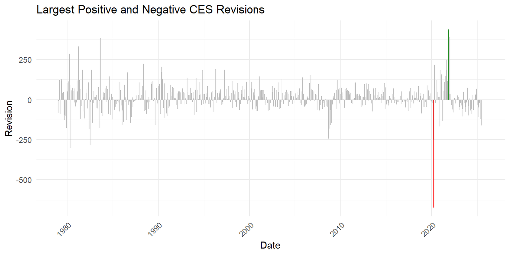

```r
df_final <- df_final %>% rename(date = Date)

df_joined <- df_final %>%
  left_join(ces_revisions, by = "date")


# Identify the largest positive and negative revisions
max_pos <- max(df_joined$revision, na.rm = TRUE)
max_neg <- min(df_joined$revision, na.rm = TRUE)

# Create a color column
df_plot <- df_joined %>%
  mutate(
    bar_color = case_when(
      revision == max_pos ~ "#228B22",
      revision == max_neg ~ "red",
      TRUE ~ "grey"
    )
  )

# Plot
ggplot(df_plot, aes(x = date, y = revision, fill = bar_color)) +
  geom_col() +
  scale_fill_identity() +
  labs(
    title = "Largest Positive and Negative CES Revisions",
    x = "Date",
    y = "Revision"
  ) +
  theme_minimal() +
  theme(
    axis.text.x = element_text(angle = 45, hjust = 1)
  )
```

```r
# Find largest positive revision
max_pos_row <- df_joined %>% filter(revision == max(revision, na.rm = TRUE))
max_pos_month <- format(max_pos_row$date, "%B %Y")
max_pos_value <- max_pos_row$revision

# Find largest negative revision
max_neg_row <- df_joined %>% filter(revision == min(revision, na.rm = TRUE))
max_neg_month <- format(max_neg_row$date, "%B %Y")
max_neg_value <- max_neg_row$revision
```

The chart above displays the monthly trend of CES revisions over the past 45 years. The largest negative revision occurred in **March 2020 with a -672 decrease**, while the largest positive revision occurred in **November 2021 with a 437 increase**. Notably, the largest decrease coincided with the month when COVID-19 was officially declared a global pandemic in the United States.

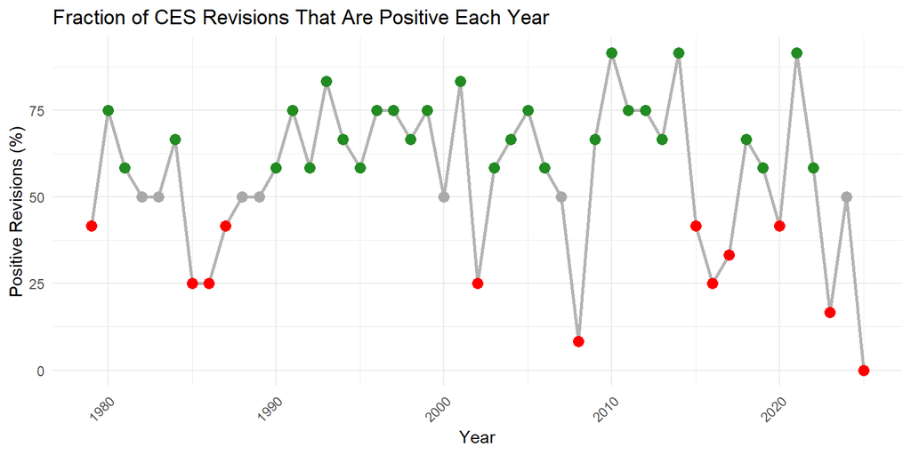

```r
library(ggplot2)
library(dplyr)
library(lubridate)

# Add year column
df_yearly <- df_joined %>%
  mutate(Year = year(date))

# Compute fraction of positive revisions per year
yearly_pos_frac <- df_yearly %>%
  group_by(Year) %>%
  summarise(
    total_revisions = n(),
    positive_revisions = sum(revision > 0, na.rm = TRUE),
    positive_fraction = positive_revisions / total_revisions * 100
  ) %>%
  # Create color column for points
  mutate(
    point_color = case_when(
      positive_fraction > 50 ~ "#228B22",
      positive_fraction < 50 ~ "red",
      positive_fraction == 50 ~ "darkgrey"
    )
  )

# Plot
ggplot(yearly_pos_frac, aes(x = Year, y = positive_fraction)) +
  geom_line(color = "grey70", size = 1) +      # same grey as previous bar chart
  geom_point(aes(color = point_color), size = 3) +
  scale_color_identity() +                     # use the colors exactly as specified
  labs(
    title = "Fraction of CES Revisions That Are Positive Each Year",
    x = "Year",
    y = "Positive Revisions (%)"
  ) +
  theme_minimal() +
  theme(
    axis.text.x = element_text(angle = 45, hjust = 1)
  )
```

The chart illustrates the yearly share of CES months that experienced a positive revision, with values plotted from 1979 to 2025. Each year is represented by a point whose color indicates whether positive revisions outweighed negative ones. Green bubbles highlight years with more than 50% positive revisions, while red bubbles represent years with more than 50% negative revisions. Overall, the trend shows that in most years, positive revisions outnumber the negative ones.

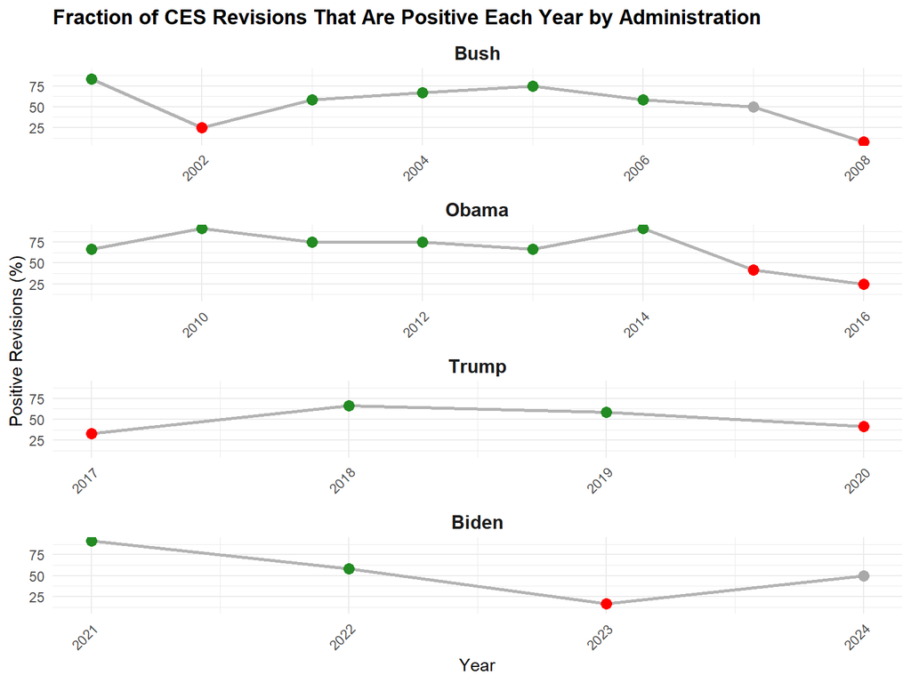

```r
library(dplyr)
library(ggplot2)
library(lubridate)

# Step 1: Add administration and year
df_admin_yearly <- df_joined %>%
  mutate(
    Administration = case_when(
      date >= as.Date("2001-01-01") & date <= as.Date("2008-12-31") ~ "Bush",
      date >= as.Date("2009-01-01") & date <= as.Date("2016-12-31") ~ "Obama",
      date >= as.Date("2017-01-01") & date <= as.Date("2020-12-31") ~ "Trump",
      date >= as.Date("2021-01-01") & date <= as.Date("2024-12-31") ~ "Biden",
      TRUE ~ NA_character_
    ),
    Year = year(date)
  ) %>%
  filter(!is.na(Administration))

# Step 2: Compute fraction of positive revisions per year AND administration
admin_yearly_frac <- df_admin_yearly %>%
  group_by(Administration, Year) %>%
  summarise(
    total_revisions = n(),
    positive_revisions = sum(revision > 0, na.rm = TRUE),
    positive_fraction = positive_revisions / total_revisions * 100,
    .groups = "drop"
  ) %>%
  mutate(
    point_color = case_when(
      positive_fraction > 50 ~ "#228B22",   # forest green
      positive_fraction < 50 ~ "red",
      positive_fraction == 50 ~ "darkgrey"
    ),
    Administration = factor(Administration, levels = c("Bush", "Obama", "Trump", "Biden")) # custom order
  )

# Step 3: Plot
ggplot(admin_yearly_frac, aes(x = Year, y = positive_fraction)) +
  geom_line(color = "grey70", size = 1) +
  geom_point(aes(color = point_color), size = 3) +
  scale_color_identity() +
  facet_wrap(~ Administration, ncol = 1, scales = "free_x") +
  labs(
    title = "Fraction of CES Revisions That Are Positive Each Year by Administration",
    x = "Year",
    y = "Positive Revisions (%)"
  ) +
  theme_minimal() +
  theme(
    strip.text = element_text(size = 12, face = "bold"),
    axis.text.x = element_text(angle = 45, hjust = 1),
    plot.title = element_text(face = "bold")
  )
```

The visualization splits the CES revisions by the last four presidential administrations: Bush, Obama, Trump, and Biden. It shows the percentage of monthly positive revisions by year. During Bush’s presidency, revisions were mostly positive, with negative years appearing toward the end, coinciding with the onset of the Great Recession in 2008. Under Obama, the majority of years were positive, though 2015 and 2016 experienced more negative months. Trump’s administration was evenly split, with two years showing predominantly positive revisions and two years predominantly negative. During Biden’s presidency, two years were positive, one year negative, and the final year was neutral.

```r
# Add Administration column
df_admin <- df_joined %>%
  mutate(Administration = case_when(
    date >= as.Date("2001-01-01") & date <= as.Date("2008-12-31") ~ "Bush",
    date >= as.Date("2009-01-01") & date <= as.Date("2016-12-31") ~ "Obama",
    date >= as.Date("2017-01-01") & date <= as.Date("2020-12-31") ~ "Trump",
    date >= as.Date("2021-01-01") & date <= as.Date("2024-12-31") ~ "Biden",
    TRUE ~ NA_character_
  )) %>%
  filter(!is.na(Administration))

# Compute percentage of positive revisions under each administration
admin_summary <- df_admin %>%
  mutate(
    Administration = factor(Administration, levels = c("Bush", "Obama", "Trump", "Biden"))
  ) %>%
  group_by(Administration) %>%
  summarise(
    total_months = n(),
    positive_months = sum(revision > 0, na.rm = TRUE),
    positive_fraction = positive_months / total_months * 100
  )

#admin_summary

admin_summary_formatted <- admin_summary %>%
  mutate(
    Positive_Fraction = sprintf("%.1f%%", positive_fraction)  # format as "xx.x%"
  ) %>%
  select(Administration, total_months, positive_months, Positive_Fraction)

datatable(
  admin_summary_formatted,
  style = "bootstrap5",
  class = "table table-striped table-hover",
  colnames = c(
    "Administration",
    "Total Months",
    "Positive Months",
    "Positive Fraction"
  ),
  options = list(
    searching = FALSE,
    info = FALSE,
    lengthChange = TRUE,
    paging = FALSE,
    initComplete = JS('function() { $("html").attr("data-bs-theme", "light"); }')
  )
)
```

|  | Administration | Total Months | Positive Months | Positive Fraction |
| --- | --- | --- | --- | --- |
| 1 | Bush | 96 | 51 | 53.1% |
| 2 | Obama | 96 | 64 | 66.7% |
| 3 | Trump | 48 | 24 | 50.0% |
| 4 | Biden | 48 | 26 | 54.2% |

Breaking the administrations out into a table, we can see the percentage of positive months for each presidency. Notably, the Democratic presidents, Obama and Biden, have the highest percentages of positive months, with **66.7% for Obama** and **54.2% for Biden**. The Republican presidents have lower percentages, with **53.1% for Bush** and **50.0% for Trump**. This comparison highlights how positive CES revisions varied across administrations.

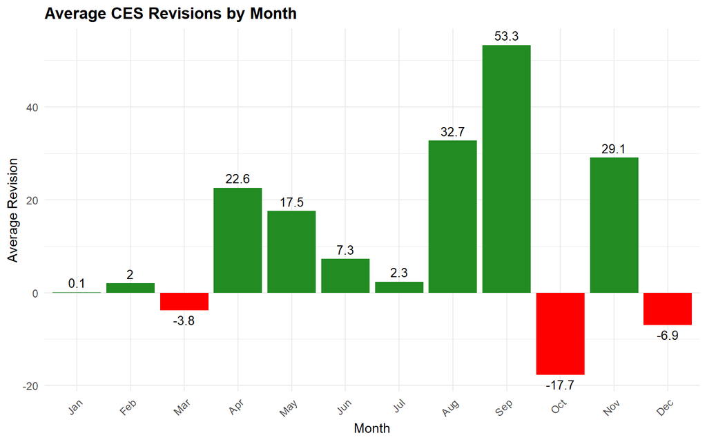

```r
# Step 1: Extract month and compute average revision
df_monthly_avg <- df_joined %>%
  mutate(Month = month(date, label = TRUE, abbr = TRUE)) %>%  # Jan, Feb, etc.
  group_by(Month) %>%
  summarise(
    avg_revision = mean(revision, na.rm = TRUE),
    .groups = "drop"
  ) %>%
  mutate(
    bar_color = ifelse(avg_revision > 0, "#228B22",  # forest green
                       ifelse(avg_revision < 0, "red", "darkgrey"))
  )

# Step 2: Plot with labels
ggplot(df_monthly_avg, aes(x = Month, y = avg_revision, fill = bar_color)) +
  geom_col() +
  geom_text(aes(label = round(avg_revision, 1)),
            vjust = ifelse(df_monthly_avg$avg_revision >= 0, -0.5, 1.5),
            color = "black", size = 3.5) +
  scale_fill_identity() +
  labs(
    title = "Average CES Revisions by Month",
    x = "Month",
    y = "Average Revision"
  ) +
  theme_minimal() +
  theme(
    axis.text.x = element_text(angle = 45, hjust = 1),
    plot.title = element_text(face = "bold")
  )
```

The chart shows that, on average, September experiences the largest positive CES revision, with an increase of 53.3. The largest negative revision occurs the following month, October, with a decrease of 17.7. Notably, the fourth quarter is the only quarter in which at least two of the three months consistently with negative revisions. This pattern suggests a seasonal effect in the CES data, with the end of the year tending to have more downward adjustments compared to earlier months.

## Statistical Analysis

One question of interest is whether the fraction of negative revisions has increased post-2000 compared to earlier periods. First we create a simple table that will highlight the count of negative months and total months in our dataset.

```r
library(dplyr)

# Step 1: Create pre-2000 and post-2000 indicator
df_test <- df_joined %>%
  filter(!is.na(revision)) %>%               # remove NAs just in case
  mutate(
    period = ifelse(date < as.Date("2000-01-01"), "Pre-2000", "Post-2000"),
    is_negative = revision < 0
  )

# Step 2: Compute counts for each period
neg_counts <- df_test %>%
  group_by(period) %>%
  summarise(
    n_negative = sum(is_negative),
    n_total = n(),
    .groups = "drop"
  )


#neg_counts  # check that there are exactly 2 rows: pre2000, post2000

datatable(
  neg_counts,
  style = "bootstrap5",
  class = "table table-striped table-hover",
  colnames = c(
    "Period",
    "Negative Months",
    "Total Months"
  ),
  options = list(
    searching = FALSE,
    info = FALSE,
    lengthChange = TRUE,
    paging = FALSE,
    initComplete = JS('function() { $("html").attr("data-bs-theme", "light"); }')
  )
)
```

|  | Period | Negative Months | Total Months |
| --- | --- | --- | --- |
| 1 | Post-2000 | 135 | 306 |
| 2 | Pre-2000 | 102 | 252 |

```r
# Step 3: Convert to numeric vectors
x <- neg_counts$n_negative
n <- neg_counts$n_total

# Step 4: Run proportion test
prop_test_result <- prop.test(x = x, n = n, alternative = "greater")
#prop_test_result

# Extract relevant info
prop_estimates <- prop_test_result$estimate         # proportions
test_stat <- prop_test_result$statistic            # X-squared
p_value <- prop_test_result$p.value                # p-value

# Create a clean data frame for display
prop_summary <- data.frame(
  Period = c("Pre-2000", "Post-2000"),
  Fraction_Negative = round(prop_estimates, 3)
)

# Print summary
datatable(
  prop_summary,
  style = "bootstrap5",
  class = "table table-striped table-hover",
  colnames = c("Period", "Fraction of Negative Months"),
  options = list(
    searching = FALSE,
    info = FALSE,
    lengthChange = TRUE,
    paging = FALSE,
    initComplete = JS('function() { $("html").attr("data-bs-theme", "light"); }')
  )
)
```

[output not shown]

## Fact Check BLS Revisions

Next we will examine the political commentary surrounding the firing of Dr. Erika McEntarfer and evaluate the claims of political bias in the CES reports. Using the data and visualizations presented throughout this report, we assess whether the claims made about distortions or unusually negative revisions are supported by the evidence. This analysis allows us to separate fact from opinion and provide an objective assessment on historical CES trends.

### Claim 1

**Senator Rick Scott, Florida (R)** Called for “somebody non-political” to replace McEntarfer. “I’d like somebody that just put out the darn numbers,” he said in an interview on Friday. “All the numbers we get up here are all massaged because somebody has an agenda.”

In our previous analysis, we observed that the revisions were slightly more frequently negative under Republican presidents, Bush and Trump, compared to Democratic presidents, Obama and Biden.

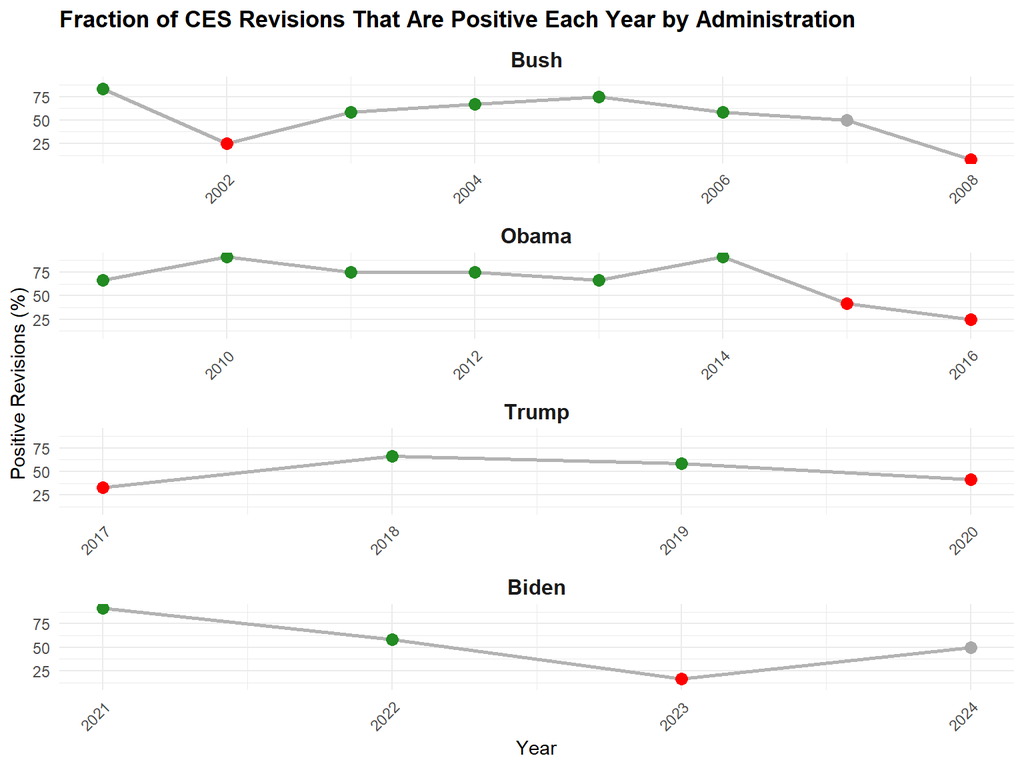

```r
ggplot(admin_yearly_frac, aes(x = Year, y = positive_fraction)) +
  geom_line(color = "grey70", size = 1) +
  geom_point(aes(color = point_color), size = 3) +
  scale_color_identity() +
  facet_wrap(~ Administration, ncol = 1, scales = "free_x") +
  labs(
    title = "Fraction of CES Revisions That Are Positive Each Year by Administration",
    x = "Year",
    y = "Positive Revisions (%)"
  ) +
  theme_minimal() +
  theme(
    strip.text = element_text(size = 12, face = "bold"),
    axis.text.x = element_text(angle = 45, hjust = 1),
    plot.title = element_text(face = "bold")
  )
```

[figure not shown]

```r
df_extreme <- df_joined %>%
  filter(!is.na(revision), !is.na(Level)) %>%
  mutate(
    Administration = case_when(
      date >= as.Date("2001-01-01") & date <= as.Date("2008-12-31") ~ "Bush",
      date >= as.Date("2009-01-01") & date <= as.Date("2016-12-31") ~ "Obama",
      date >= as.Date("2017-01-01") & date <= as.Date("2020-12-31") ~ "Trump",
      date >= as.Date("2021-01-01") & date <= as.Date("2024-12-31") ~ "Biden",
      TRUE ~ NA_character_
    ),
    #revision_pct = abs(revision) / Level,       # convert to fraction
    revision_pct = revision / Level,       # convert to fraction
    #is_extreme = revision_pct > 0.001      # convert to fraction
    is_extreme = revision_pct < -0.001           # >1% of total employment
  ) %>%
  filter(!is.na(Administration))

# Step 2: Count extreme revisions by administration
extreme_summary <- df_extreme %>%
  group_by(Administration) %>%
  summarise(
    total_months = n(),
    extreme_months = sum(is_extreme),
    fraction_extreme = extreme_months / total_months * 100,
    .groups = "drop"
  )

# Step 3: Display table


# Step 4: Optional bar chart
ggplot(extreme_summary, aes(x = Administration, y = fraction_extreme, fill = Administration)) +
  geom_col() +
  geom_text(aes(label = round(fraction_extreme, 1)), vjust = -0.5) +
  scale_fill_manual(values = c("Bush" = "red", "Obama" = "blue", "Trump" = "red", "Biden" = "blue")) +
  labs(
    title = "Fraction of CES Months with Extreme Negative Revisions (>.01% of Level)",
    x = "Administration",
    y = "Fraction of Extreme Negative Months (%)"
  ) +
  theme_minimal() +
  theme(
    plot.title = element_text(face = "bold"),
    legend.position = "none"
  )
```

```r
# Filter for extreme revisions and add administration
df_extreme_months <- df_joined %>%
  filter(!is.na(revision), !is.na(Level)) %>%
  mutate(
    Administration = case_when(
      date >= as.Date("2001-01-01") & date <= as.Date("2008-12-31") ~ "Bush",
      date >= as.Date("2009-01-01") & date <= as.Date("2016-12-31") ~ "Obama",
      date >= as.Date("2017-01-01") & date <= as.Date("2020-12-31") ~ "Trump",
      date >= as.Date("2021-01-01") & date <= as.Date("2024-12-31") ~ "Biden",
      TRUE ~ NA_character_
    ),
    revision_pct = revision / Level,
    is_extreme = revision_pct < -0.001,   # 0.01% threshold
    direction = ifelse(revision_pct > 0, "Positive", "Negative")
  ) %>%
  filter(!is.na(Administration), is_extreme) %>%
  select(Date = date, Administration, Revision = revision, `Revision (%)` = revision_pct, Direction = direction)

# Display table
datatable(
  df_extreme_months,
  style = "bootstrap5",
  class = "table table-striped table-hover",
  options = list(
    searching = FALSE,
    info = FALSE,
    lengthChange = TRUE,
    paging = FALSE,
    initComplete = JS('function() { $("html").attr("data-bs-theme", "light"); }')
  )
)
```

|  | Date | Administration | Revision | Revision (%) | Direction |
| --- | --- | --- | --- | --- | --- |
| 1 | 2008-09-01 | Bush | -244 | -0.001784121320249777 | Negative |
| 2 | 2008-10-01 | Bush | -183 | -0.001342695516277432 | Negative |
| 3 | 2008-12-01 | Bush | -157 | -0.001164282483110488 | Negative |
| 4 | 2009-01-01 | Obama | -143 | -0.001066543355360313 | Negative |
| 5 | 2020-03-01 | Trump | -672 | -0.004453427880314126 | Negative |
| 6 | 2020-04-01 | Trump | -250 | -0.001916825124210268 | Negative |
| 7 | 2020-12-01 | Trump | -166 | -0.00116452002132615 | Negative |

[figure not shown]

**Mostly False** for Rick Scott’s claim that “numbers are massaged”

### Claim 2

**Doug Holtz-Eakin, American Action Forum** “The president is just shooting the messenger, it’s not more complicated than that. The data that were released today conformed in every way to the standards of past employment reports.”

To evaluate this claim, we examine whether the June 2025 employment revision was unusually large compared with historical patterns. Specifically, we calculate the revision as a percentage of the original employment level and measure how many standard deviations it deviates from the long-term average revision percentage. This allows us to determine objectively whether the June 2025 data falls within the normal range of past employment reports.

```r
df_june <- df_joined |>
  filter(date == as.Date("2025-06-01"))


datatable(
  df_june,
  style = "bootstrap5",
  class = "table table-striped table-hover",
  colnames = c(
    "Date",
    "Level",
    "Original",
    "Final",
    "Revision"
  ),
  options = list(
    searching = FALSE,
    info = FALSE,
    lengthChange = TRUE,
    paging = FALSE,
    initComplete = JS('function() { $("html").attr("data-bs-theme", "light"); }')
  )
)
```

|  | Date | Level | Original | Final | Revision |
| --- | --- | --- | --- | --- | --- |
| 1 | 2025-06-01 | 159439 | 147 | -13 | -160 |

```r
# 1. Extract June 2025 revision and keep numeric %
latest <- df_joined %>%
  filter(date == as.Date("2025-06-01")) %>%
  mutate(
    revision_pct = revision / Level * 100   # numeric only
  )

# store numeric value
latest_rev <- latest


june_percent <- df_joined %>%
  filter(date == as.Date("2025-06-01")) %>%
  mutate(revision_pct = revision / Level * 100) %>%
  pull(revision_pct)

# Now format it
june_percent <- sprintf("%.2f%%", june_percent)

# 2. Historical stats (numeric)
hist_stats <- df_joined %>%
  filter(date < as.Date("2025-06-01")) %>%
  mutate(revision_pct = revision / Level * 100) %>%
  summarise(
    mean_rev = mean(revision_pct, na.rm = TRUE),
    sd_rev   = sd(revision_pct, na.rm = TRUE)
  )

hist_percent <- df_joined %>%
  filter(date < as.Date("2025-06-01")) %>%
  mutate(revision_pct = revision / Level * 100) %>%
  summarise(mean_rev = mean(revision_pct, na.rm = TRUE)) %>%
  pull(mean_rev)

# Format as a percent string
hist_percent_formatted <- sprintf("%.2f%%", hist_percent)

# 3. Compute Z-score
z_score <- (latest_rev$revision_pct - hist_stats$mean_rev) / hist_stats$sd_rev

# 4. Create formatted table for display
result <- tibble(
  date = latest_rev$date,
  revision = latest_rev$revision,
  level = latest_rev$Level,
  revision_pct = sprintf("%.2f%%", latest_rev$revision_pct),
  historical_mean_pct = sprintf("%.2f%%", hist_stats$mean_rev),
  historical_sd_pct = sprintf("%.4f", hist_stats$sd_rev),
  z_score = sprintf("%.2f", z_score)
)


z_score_output <- result$z_score
```

**June 2025**: -0.10% Revision

**Historical Average, since 1979**: 0.01% Revision

**Z-Score**: -1.52

The June 2025 revision came in at –1.52 standard deviations from the historical average revision percentage. While this is below the long-run mean, the value is still within the range of normal month-to-month variation for employment data. In statistical terms, a deviation of this size is not extreme and does not indicate an unusual or atypical report. Based on this measure, the June 2025 release does not materially depart from the historical pattern, which lends support to the claim that the data “conformed in every way to the standards of past employment reports.”

[figure not shown]

**True** for Doug Holtz-Eakin’s claim that data “conformed to past reports”

## Conclusion

Overall, our analysis indicates that CES revisions, while variable, generally follow predictable patterns influenced by economic cycles and seasonal effects rather than political interference. Extreme revisions are rare and typically coincide with extraordinary events, such as the COVID-19 pandemic, rather than administrative bias. The June 2025 report and historical trends further confirm that the BLS consistently produces data that align with established standards, supporting the reliability and integrity of its employment statistics.